# Judicial Decision-making based on Interpretations of Science (JuDIS)

Project: Judicial Decision-making based on Interpretations of Science

Abstract: The present study surveyed judges to examine how they consider and apply scientific information during sentencing determinations. Our results provided unique insights into the ways in which judges assess cases and consider sentencing outcomes when presented with scientific information to explicate defendants' behavior.

Data: This demo uses data from interviews with 34 U.S. criminal court judges that I collected in 2023.

This project was published as:

1. Influence of scientific evidence on judges’ views and sentencing decision-making: Natural Language Processing and qualitative analysis.
2. Bio-behavioral scientific evidence alters judges' sentencing decision-making: A quantitative analysis.

Please note that this notebook contains only a small example from the analyses performed for this project. The purpose of this notebook is to demonstrate the thought process and types of analyses performed and is not exhaustive or complete. The full analyses performed for each project are reported in the published article.

## Load libraries

```python
# Basic libraries
import pandas as pd
import numpy as np

# Libraries for graphs
import matplotlib.pyplot as plt
import matplotlib.gridspec as gridspec
from matplotlib import cm
from matplotlib.ticker import StrMethodFormatter
from matplotlib.ticker import FuncFormatter
import matplotlib.patches as patches
import seaborn as sns
from IPython.display import Image

# Libraries for inferential stats
from pandas.api.types import CategoricalDtype
import patsy
from patsy import dmatrices

import statsmodels.api as sm
from statsmodels.stats.diagnostic import het_breuschpagan
from statsmodels.stats.stattools import jarque_bera
from statsmodels.formula.api import ols
from statsmodels.miscmodels.ordinal_model import OrderedModel
from statsmodels.graphics.factorplots import interaction_plot
from statsmodels.stats.mediation import Mediation

import scipy
from scipy import stats
from scipy.stats import shapiro
from scipy.stats import zscore

import sklearn
from sklearn.compose import ColumnTransformer
from sklearn.linear_model import LinearRegression
from sklearn.preprocessing import LabelEncoder, OneHotEncoder
from sklearn.model_selection import train_test_split
from sklearn.metrics import confusion_matrix, classification_report
from sklearn.feature_extraction.text import CountVectorizer
from sklearn.feature_extraction.text import TfidfVectorizer
from sklearn.decomposition import LatentDirichletAllocation
from sklearn.decomposition import TruncatedSVD
from sklearn.pipeline import Pipeline
from sklearn.cluster import KMeans
from sklearn.decomposition import PCA
from sklearn.manifold import TSNE
from sklearn.metrics.pairwise import cosine_similarity

from transformers import BertTokenizer, Trainer, TrainingArguments
import torch

import nltk
from nltk.corpus import stopwords
from nltk.tokenize import word_tokenize
from nltk.sentiment.vader import SentimentIntensityAnalyzer
from nltk.corpus import sentiwordnet as swn
from nltk.corpus import wordnet as wn
nltk.download('punkt')
nltk.download('stopwords')
nltk.download('vader_lexicon')
nltk.download('sentiwordnet')
nltk.download('wordnet')
nltk.download('nrc_lexicon')
nltk.download('punkt')

from gensim.models import Word2Vec
from wordcloud import WordCloud
from textblob import TextBlob
import re
```

## Load data

```python
## Load dataset as df

# Define path and load data
dfQUAL = pd.read_csv('/Users/miat./Documents/OtherWork/Jobs-Grants/Portfolio/Jupyter/JuDISqual/JuDIS-Data-MAIN-For-Qual-Mia.csv')
```

## Cleaning for quantitative analysis

```python
## Change the names of variables
dfQUAL.rename(columns={'Code-CJ-Treatment-Options': 'Code-CJ-Treatment-Opt'}, inplace=True)

# Check
dfQUAL.columns

## Convert categorical num variables to continuous numerical
# For dfQUAL
dfQUAL.loc[:, 'GOAL-Rehab-HEALTHY':
              'FriendsSocialAcceptance-DISORDER'] = dfQUAL.loc[:, 'GOAL-Rehab-HEALTHY':
                                                                'FriendsSocialAcceptance-DISORDER'].astype(int)
dfQUAL['PercentChance-Recidivism-HEALTHY'] = dfQUAL['PercentChance-Recidivism-HEALTHY'].astype(int)
dfQUAL['NUM-RateYour-Knowl-BioBehavSci'] = dfQUAL['NUM-RateYour-Knowl-BioBehavSci'].astype(int)
dfQUAL['Politics-Scale-1L-5R'] = dfQUAL['Politics-Scale-1L-5R'].astype(int)

## Fix order
dfQUAL['PriorWork'] = pd.Categorical(dfQUAL['PriorWork'], ['DefenseAtt/PublicDefender',
                                                           'PublicDefender',
                                                           'DefenseAtt/Corrections',
                                                           'Civil/FamilyLaw',
                                                           'DefenseAttorney',
                                                           'DefenseAtt/PublicDef/Prosecutor',
                                                           'PublicDefender/Prosecutor',
                                                           'DefenseAtt/Prosecutor',
                                                           'Prosecutor'],
ordered=True)

## Renamed version
dfQUAL['Prior Work'] = dfQUAL['PriorWork'].replace({'DefenseAtt/PublicDefender': 'DefAtt/PubDef',
                                                   'PublicDefender': 'PubDef',
                                                   'DefenseAtt/Corrections': 'Corrections',
                                                   'Civil/FamilyLaw': 'CivilLaw',
                                                   'DefenseAttorney': 'DefAtt',
                                                   'DefenseAtt/PublicDef/Prosecutor': 'DefAtt/Prosec',
                                                   'PublicDefender/Prosecutor': 'PubDef/Prosec',
                                                   'DefenseAtt/Prosecutor': 'DefAtt/Prosec',
                                                   'Prosecutor': 'Prosecutor'})

# Fix order
dfQUAL['Politics'] = pd.Categorical(dfQUAL['Politics'], ['Blue',
                                                         'Purple',
                                                         'Red'])

# Fix order
dfQUAL['Politics-Leaning'] = pd.Categorical(dfQUAL['Politics-Leaning'], ['Liberal',
                                                                         'Middle',
                                                                         'Conservative'])
# Fix order
dfQUAL['Age'] = pd.Categorical(dfQUAL['Age'], ['40-49',
                                               '50-59',
                                               '60-69',
                                               '70-80'])

# Fix order
dfQUAL['Years-Judge-Career'] = pd.Categorical(dfQUAL['Years-Judge-Career'], ['0--5',
                                                                             '5--9',
                                                                             '10--19',
                                                                             '20--29',
                                                                             '30--40'])

# Fix order
dfQUAL['Religious'] = pd.Categorical(dfQUAL['Religious'], ['No',
                                                           'aLittle',
                                                           'Yes'])

# Fix order
dfQUAL['Geo'] = pd.Categorical(dfQUAL['Geo'], ['West',
                                               'MidWest',
                                               'South'])

# Fix order
dfQUAL['BELIEFinDetermTotalThresh'] = pd.Categorical(dfQUAL['BELIEFinDetermTotalThresh'], ['High',
                                                                                           'Moderate',
                                                                                           'Low'])
```

## Summary Statistics

```python
### Calculate mean values for many variables

# Select specific columns from dfQUAL
numerical_view = ['Dangerous-HEALTHY', 'Dangerous-DISORDER',
                  'Immutable-Untreat-HEALTHY', 'Immutable-Untreat-DISORDER',
                  'Responsible-HEALTHY', 'Responsible-DISORDER',
                  'FriendsSocialAcceptance-HEALTHY', 'FriendsSocialAcceptance-DISORDER',
                  'FreeWill-HEALTHY', 'FreeWill-DISORDER']

# Calculate mean values for selected columns along axis=1
mean_view = dfQUAL[numerical_view].mean()

# Show means
print(mean_view)
```

```
Dangerous-HEALTHY                   2.911765
Dangerous-DISORDER                  3.117647
Immutable-Untreat-HEALTHY           1.852941
Immutable-Untreat-DISORDER          2.117647
Responsible-HEALTHY                 4.441176
Responsible-DISORDER                3.088235
FriendsSocialAcceptance-HEALTHY     3.470588
FriendsSocialAcceptance-DISORDER    3.558824
FreeWill-HEALTHY                    4.264706
FreeWill-DISORDER                   2.735294
dtype: float64
```

```python
### Cross-tabulate 'Politics-Leaning' and 'Politics'
cross_tab = pd.crosstab(dfQUAL['Politics-Leaning'], dfQUAL['Politics'])

# Calculate percentages
cross_tab_percent = cross_tab.apply(lambda x: x / x.sum() * 100, axis=1).round(2)

# Print results
print("\n")
print(cross_tab)
print("\n")
print(cross_tab_percent)
```

```
Politics          Blue  Purple  Red
Politics-Leaning
Liberal              8       4    3
Middle               4       3    2
Conservative         0       1    9


Politics           Blue  Purple    Red
Politics-Leaning
Liberal           53.33   26.67  20.00
Middle            44.44   33.33  22.22
Conservative       0.00   10.00  90.00
```

```python
### Calculate mean determinism score across different variable categories

## Gender
mean_determinism_score_gender = dfQUAL.groupby('Gender', observed=False)['BELIEFinDetermRandom-NoFreewill-Score10to50'].mean()
# Print
print(mean_determinism_score_gender)

## Age
mean_determinism_score_age = dfQUAL.groupby('Age', observed=False)['BELIEFinDetermRandom-NoFreewill-Score10to50'].mean()
# Print
print(mean_determinism_score_age)

## Geo
mean_determinism_score_region = dfQUAL.groupby('Geo', observed=False)['BELIEFinDetermRandom-NoFreewill-Score10to50'].mean()
# Print
print(mean_determinism_score_region)

## Politics-Leaning
mean_determinism_score_politics = dfQUAL.groupby('Politics-Leaning', observed=False)['BELIEFinDetermRandom-NoFreewill-Score10to50'].mean()
# Print
print(mean_determinism_score_politics)

## Religious
mean_determinism_score_rel = dfQUAL.groupby('Religious', observed=False)['BELIEFinDetermRandom-NoFreewill-Score10to50'].mean()
# Print
print(mean_determinism_score_rel)
```

```
Gender
F    25.7
M    29.5
Name: BELIEFinDetermRandom-NoFreewill-Score10to50, dtype: float64
Age
40-49    29.111111
50-59    28.400000
60-69    28.692308
70-80    23.000000
Name: BELIEFinDetermRandom-NoFreewill-Score10to50, dtype: float64
Geo
West       29.416667
MidWest    30.300000
South      25.750000
Name: BELIEFinDetermRandom-NoFreewill-Score10to50, dtype: float64
Politics-Leaning
Liberal         30.733333
Middle          30.222222
Conservative    23.200000
Name: BELIEFinDetermRandom-NoFreewill-Score10to50, dtype: float64
Religious
No         30.428571
aLittle    30.000000
Yes        26.588235
Name: BELIEFinDetermRandom-NoFreewill-Score10to50, dtype: float64
```

```python
#### Calculate factors considered by Judges + cross-tabulate for grouping variables

### Dangerousn-Factor-Consider (do they consider the dangerousness of the offender)
## Calculate totals
# Calculate count totals
total_counts_f = dfQUAL['Dangerousn-Factor-Consider'].value_counts()
# Calculate percentage totals
total_percentages_f = (total_counts_f / len(dfQUAL) * 100).round(1)
## Cross-tabulate
# Cross-tabulate counts based on politics
cross_tab_f1 = pd.crosstab(dfQUAL['Dangerousn-Factor-Consider'], dfQUAL['Politics-Leaning'])
# Cross-tabulate percentages
cross_tab_percent_f1 = cross_tab_f1.apply(lambda x: x / x.sum() * 100, axis=1).round(1)
# Cross-tab total column
cross_tab_f1['Total'] = cross_tab_f1.sum(axis=1)
# Cross-tabulate counts other var
cross_tab_f2 = pd.crosstab(dfQUAL['Dangerousn-Factor-Consider'], dfQUAL['Religious'])
# Cross-tabulate percentages other var
cross_tab_percent_f2 = cross_tab_f2.apply(lambda x: x / x.sum() * 100, axis=1).round(1)
# Cross-tab total column other var
cross_tab_f2['Total'] = cross_tab_f2.sum(axis=1)

## Print
print("\nCounts total:\n", total_counts_f)
print("\nPercentage total:\n", total_percentages_f)
print("\nCounts cross-tab:\n", cross_tab_f1)
print("\nPercentage cross-tab:\n", cross_tab_percent_f1)
print("\nCounts cross-tab:\n", cross_tab_f2)
print("\nPercentage cross-tab:\n", cross_tab_percent_f2)
```

```
Counts total:
 Dangerousn-Factor-Consider
No     27
Yes     7
Name: count, dtype: int64

Percentage total:
 Dangerousn-Factor-Consider
No     79.4
Yes    20.6
Name: count, dtype: float64

Counts cross-tab:
 Politics-Leaning            Liberal  Middle  Conservative  Total
Dangerousn-Factor-Consider
No                               11       7             9     27
Yes                               4       2             1      7

Percentage cross-tab:
 Politics-Leaning            Liberal  Middle  Conservative
Dangerousn-Factor-Consider
No                             40.7    25.9          33.3
Yes                            57.1    28.6          14.3

Counts cross-tab:
 Religious                   No  aLittle  Yes  Total
Dangerousn-Factor-Consider
No                           6        7   14     27
Yes                          1        3    3      7

Percentage cross-tab:
 Religious                     No  aLittle   Yes
Dangerousn-Factor-Consider
No                          22.2     25.9  51.9
Yes                         14.3     42.9  42.9
```

## Tables

```python
### Categorical variable example

## Gender - example variable

# Get counts
outcome_counts = dfQUAL.groupby('Gender')['CodeAnon'].count()

# Calculate the total count of participants
total_participants = outcome_counts.sum()

# Calculate the percentage of participants
percent_participants = (outcome_counts / total_participants * 100).round(2)

# Create a DataFrame with the results
result_df_a = pd.DataFrame({'Count': outcome_counts, 'Percentage': percent_participants})

# Print the result DataFrame
print(result_df_a)

# Optionally Export to Excel to start building table for executive summary
#result_df_a.to_excel('SumStatsCatT1-a.xlsx', index=True)
```

```
        Count  Percentage
Gender
F          10       29.41
M          24       70.59
```

```python
### Numerical variables example

## Sentences for fictional cases - example variable

# Define the specific columns to include in the summary table
columns_incl = ['Dangerous-HEALTHY', 'Dangerous-DISORDER',
                  'Immutable-Untreat-HEALTHY', 'Immutable-Untreat-DISORDER',
                  'Responsible-HEALTHY', 'Responsible-DISORDER',
                  'FriendsSocialAcceptance-HEALTHY', 'FriendsSocialAcceptance-DISORDER',
                  'FreeWill-HEALTHY', 'FreeWill-DISORDER'
                      ]

# Define grouping variable
grouping_variable = 'Politics-Leaning'

# Group your data by a categorical variable and get means/sd of the numerical vars
grouped_data = dfQUAL.groupby(grouping_variable, observed=False)[columns_incl].agg(['mean', 'std']).round(1)

# Reset the index to make the grouping variable a regular column
grouped_data.reset_index(inplace=True)

# Transpose the table so that Politics is in columns
transposed_data = grouped_data.transpose()

# Print
print(transposed_data)

# Optionally Export to Excel to start building table for executive summary
#transposed_data.to_excel('SumStatsContT1.xlsx', index=True)
```

```
                                             0       1             2
Politics-Leaning                       Liberal  Middle  Conservative
Dangerous-HEALTHY                mean      3.0     2.9           2.8
                                 std       0.8     0.9           1.1
Dangerous-DISORDER               mean      2.9     3.3           3.2
                                 std       0.7     0.9           0.9
Immutable-Untreat-HEALTHY        mean      1.7     2.1           1.8
                                 std       0.9     0.9           1.0
Immutable-Untreat-DISORDER       mean      1.9     2.6           2.1
                                 std       1.1     1.0           0.9
Responsible-HEALTHY              mean      4.5     4.9           4.0
                                 std       0.7     0.3           0.8
Responsible-DISORDER             mean      3.3     3.6           2.4
                                 std       1.0     1.0           1.2
FriendsSocialAcceptance-HEALTHY  mean      3.3     3.7           3.5
                                 std       1.2     0.9           1.3
FriendsSocialAcceptance-DISORDER mean      3.3     3.8           3.7
                                 std       1.2     0.8           1.3
FreeWill-HEALTHY                 mean      4.5     4.3           3.8
                                 std       0.6     0.9           0.8
FreeWill-DISORDER                mean      2.7     3.0           2.5
                                 std       1.1     1.1           0.8
```

## Graphs

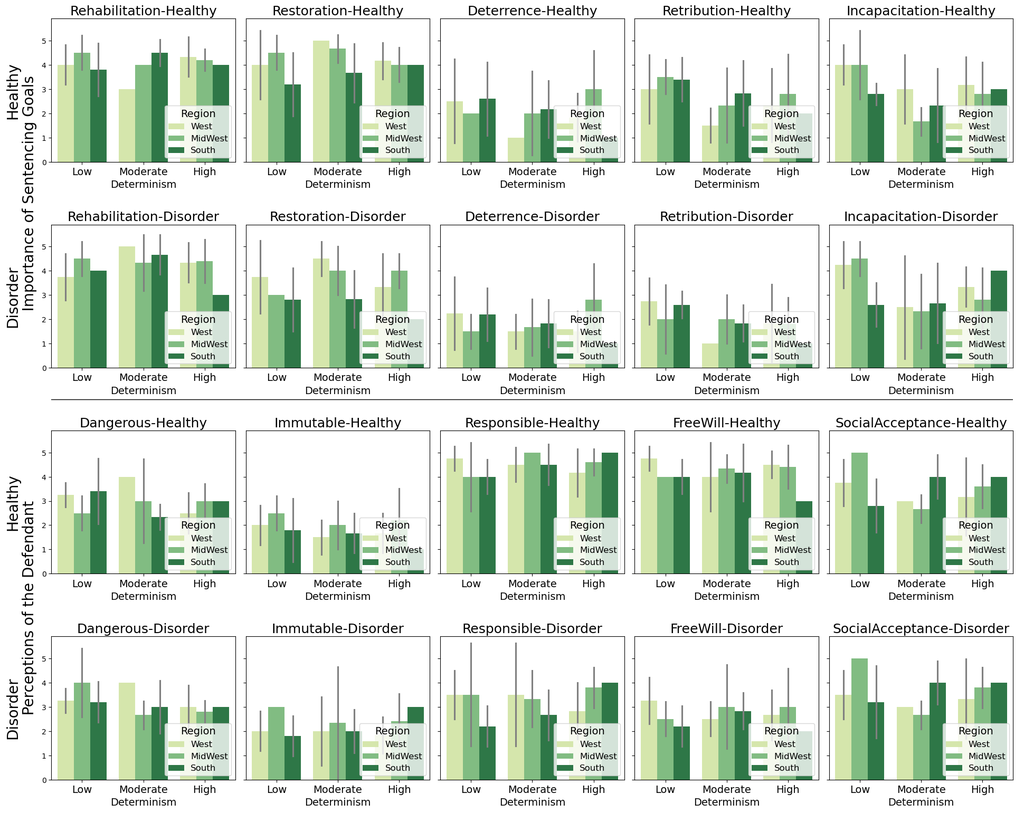

```python
### Example panel plot for goals and views Healthy vs Disorder

## I deactivate warnings that excessively indicate FutureWarning about default behavior of pd groupby operation.
import warnings
warnings.filterwarnings('ignore')

## Change the names of variables
dfQUAL.rename(columns={'GOAL-Rehab-HEALTHY': 'Rehabilitation-Healthy',
    'GOAL-Restore-HEALTHY': 'Restoration-Healthy',
    'GOAL-Deter-HEALTHY': 'Deterrence-Healthy',
    'GOAL-Retrib-HEALTHY': 'Retribution-Healthy',
    'GOAL-Incap-HEALTHY': 'Incapacitation-Healthy',
    'GOAL-Rehab-DISORDER': 'Rehabilitation-Disorder',
    'GOAL-Restore-DISORDER': 'Restoration-Disorder',
    'GOAL-Deter-DISORDER': 'Deterrence-Disorder',
    'GOAL-Retrib-DISORDER': 'Retribution-Disorder',
    'GOAL-Incap-DISORDER': 'Incapacitation-Disorder',
    'Dangerous-HEALTHY': 'Dangerous-Healthy',
    'Immutable-Untreat-HEALTHY': 'Immutable-Healthy',
    'Responsible-HEALTHY': 'Responsible-Healthy',
    'FreeWill-HEALTHY': 'FreeWill-Healthy',
    'FriendsSocialAcceptance-HEALTHY': 'SocialAcceptance-Healthy',
    'Dangerous-DISORDER': 'Dangerous-Disorder',
    'Immutable-Untreat-DISORDER': 'Immutable-Disorder',
    'Responsible-DISORDER': 'Responsible-Disorder',
    'FreeWill-DISORDER': 'FreeWill-Disorder',
    'FriendsSocialAcceptance-DISORDER': 'SocialAcceptance-Disorder'}, inplace=True)

# Define the specific columns and grouping variables
columns_to_plot = ['Rehabilitation-Healthy','Restoration-Healthy','Deterrence-Healthy','Retribution-Healthy', 'Incapacitation-Healthy',
                   'Rehabilitation-Disorder','Restoration-Disorder','Deterrence-Disorder','Retribution-Disorder','Incapacitation-Disorder',
                   'Dangerous-Healthy','Immutable-Healthy','Responsible-Healthy','FreeWill-Healthy','SocialAcceptance-Healthy',
                   'Dangerous-Disorder','Immutable-Disorder','Responsible-Disorder','FreeWill-Disorder','SocialAcceptance-Disorder']

grouping_variable1 = 'BELIEFinDetermTotalThresh'
grouping_variable2 = 'Geo'

# Group by the grouping variables and calculate means for numerical variables
grouped_data1 = dfQUAL.groupby(grouping_variable1, observed=False)[columns_to_plot].mean().reset_index()
grouped_data2 = dfQUAL.groupby(grouping_variable2, observed=False)[columns_to_plot].mean().reset_index()

# Define the organization of variables
row_order = ['Rehabilitation-Healthy','Restoration-Healthy','Deterrence-Healthy','Retribution-Healthy', 'Incapacitation-Healthy',
                   'Rehabilitation-Disorder','Restoration-Disorder','Deterrence-Disorder','Retribution-Disorder','Incapacitation-Disorder',
                   'Dangerous-Healthy','Immutable-Healthy','Responsible-Healthy','FreeWill-Healthy','SocialAcceptance-Healthy',
                   'Dangerous-Disorder','Immutable-Disorder','Responsible-Disorder','FreeWill-Disorder','SocialAcceptance-Disorder']


# Create a bar graph figure with subplots
num_rows = 4
num_cols = 5
fig, axs = plt.subplots(num_rows, num_cols, figsize=(20, 16), sharey=True)

# Define custom color palette
custom_palette = sns.color_palette("YlGn", 3)

# Plotting function with legend at bottom right
def plot_barplot(data, x_variable, y_variable, ax, palette):
    sns.barplot(x=x_variable, y=y_variable, data=dfQUAL, ax=ax,
                palette=palette, hue=grouping_variable2, errorbar='sd', errcolor='grey')
    ax.set_xlabel("Determinism", fontsize=14)
    ax.set_ylabel("")
    legend = ax.legend(loc='lower right', title="Region", fontsize=11)
    legend.set_title("Region", prop={'size': 14})
    for label in legend.get_texts():
        label.set_fontsize(12)

# Adjust x-axis label font size
for ax in axs.flat:
    ax.tick_params(axis='x', labelsize=14)

# Plotting goals
for i, column in enumerate(row_order[:10]):
    row = i // num_cols
    col = i % num_cols
    plot_barplot(grouped_data1, grouping_variable1, column, axs[row, col], custom_palette)
    axs[row, col].set_title(column, fontsize=18, pad=5, loc='center')

# Plotting views
for i, column in enumerate(row_order[10:]):
    row = (i + 10) // num_cols
    col = (i + 10) % num_cols
    plot_barplot(grouped_data1, grouping_variable1, column, axs[row, col], custom_palette)
    axs[row, col].set_title(column, fontsize=18, pad=5, loc='center')

# Set y-axis labels for each row
for i, ax in enumerate(axs):
    if i == 0:
        ax[0].set_ylabel('Healthy\n ', fontsize=20, labelpad=6)
    elif i == 1:
        ax[0].set_ylabel('Disorder\n                                            Importance of Sentencing Goals', fontsize=20, labelpad=6)
    elif i == 2:
        ax[0].set_ylabel('Healthy\n ', fontsize=20, labelpad=6)
    elif i == 3:
        ax[0].set_ylabel('Disorder\n                                           Perceptions of the Defendant', fontsize=20, labelpad=6)

# Draw a horizontal black line to separate the top two rows from the bottom two rows
line_y = num_rows / 2  #the y-coordinate where you want to draw the line
fig.add_subplot(111, frameon=False)
plt.tick_params(labelcolor='none', top=False, bottom=False, left=False, right=False)
plt.axhline(y=line_y, color='black', linewidth=1)
plt.ylabel('', fontsize=1, labelpad=1)
plt.subplots_adjust(hspace=6)  #adjust vertical space between subplots

plt.tight_layout()
plt.show()
```

## Natural Language Processing

### Sentiment Analysis

Cleaning for sentiments:

```python
# Cleaning

# Define stop words
stop_words = set(stopwords.words('english'))
custom_stop_words = {'think', 'know', 're', 'would', 'going', 'they', 'things', 'got',
                     'get', 'want', 'way', 'try', 'lot', 'make', 'see', 'go', 'may',
                     'say', 'something', 'people', 'person', 'really', 'someone', 'come',
                     'came', 'small', 'kind', 'could', 'even', 'like', 'much', 'less',
                     'sense', 'time', 'well', 'consider', 'still', 'give', 'na', 'gon','sides','situation',
                     'seeing', 'let', 'weeks', 'somebody','put', 'one', 'two', 'full',
                     'leave', 'cars', 'generally', 'place', 'compared', 'found', 'background', 'us'}
stop_words = stop_words.union(custom_stop_words)

# Define contraction mapping dictionary
contractions_mapping = {
    "i'm": "i am",
    "i've": "i have",
    "i'll": "i will",
    "we're": "we are",
    "we've": "we have",
    "we'll": "we will",
    "you're": "you are",
    "you've": "you have",
    "you'll": "you will",
    "he's": "he is",
    "he'll": "he will",
    "she's": "she is",
    "she'll": "she will",
    "it's": "it is",
    "it'll": "it will",
    "they're": "they are",
    "they've": "they have",
    "they'll": "they will",
}

# Function to expand contractions
def expand_contractions(text, contractions_mapping):
    pattern = re.compile(r'\b(' + '|'.join(contractions_mapping.keys()) + r')\b')
    def expand_match(contraction):
        return contractions_mapping[contraction.group(0)]
    expanded_text = pattern.sub(expand_match, text)
    return expanded_text

# Function to clean and preprocess text
def clean_text(text):
    # Remove non-alphabetic characters
    text = re.sub('[^A-Za-z]', ' ', text)
    # Convert to lowercase
    text = text.lower()
    # Expand contractions
    text = expand_contractions(text, contractions_mapping)
    # Tokenize the text
    tokens = word_tokenize(text)
    # Remove stopwords
    cleaned_text = ' '.join([word for word in tokens if word not in stop_words])
    return cleaned_text

# Apply cleaning
dfQUAL['Cleaned_Transcript'] = dfQUAL['TranscriptFull'].apply(clean_text)

cleaned_transcripts = dfQUAL['Cleaned_Transcript']
```

Sentiment Positive/Negative Between-Groups Panel Plot:

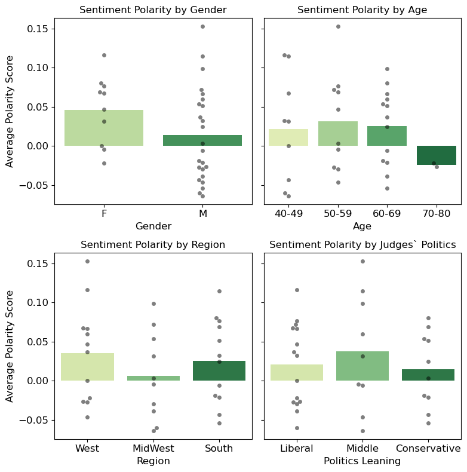

```python
#### Panel Plot for Between Groups Sentiment NLP

## Do not use function to loop through panels
#  as each needs different specifications for overal readabilty

## Using TextBlob, sentiment score represents the polarity of the text.
#  The polarity score ranges from -1 to 1, where:
#  Negative values indicate negative sentiment.
#  Positive values indicate positive sentiment.
#  Zero indicates a neutral sentiment.

## Sentiment Analysis (TextBlob)
def analyze_sentiment(text):
    blob = TextBlob(text)
    sentiment_score = blob.sentiment.polarity
    if sentiment_score > 0:
        return 'Positive'
    elif sentiment_score < 0:
        return 'Negative'
    else:
        return 'Neutral'

sentiments = cleaned_transcripts.apply(analyze_sentiment)
sentiment_counts = sentiments.value_counts()

## Panel plot
# Create subplots
fig, axs = plt.subplots(2, 2, figsize=(8, 8))

# Plot 1: Gender
grouped_sentiments = pd.DataFrame({'Polarity': cleaned_transcripts.apply(lambda x: TextBlob(x).sentiment.polarity),
                                   'Gender': dfQUAL['Gender']})
grouped_sentiments = grouped_sentiments.groupby('Gender').mean().reset_index()

sns.barplot(data=grouped_sentiments, x='Gender', y='Polarity', hue='Gender',
            palette='YlGn', ax=axs[0, 0], dodge=False)
sns.swarmplot(data=pd.DataFrame({'Polarity': cleaned_transcripts.apply(lambda x: TextBlob(x).sentiment.polarity),
                                 'Gender': dfQUAL['Gender']}), x='Gender', y='Polarity',
                                  color='black', alpha=0.5, ax=axs[0, 0])
axs[0, 0].set_title('Sentiment Polarity by Gender', fontsize=12)
axs[0, 0].set_xlabel('Gender', fontsize=12)
axs[0, 0].set_ylabel('Average Polarity Score', fontsize=12)
axs[0, 0].tick_params(axis='both', which='major', labelsize=12)

# Plot 2: Age
grouped_sentiments = pd.DataFrame({'Polarity': cleaned_transcripts.apply(lambda x: TextBlob(x).sentiment.polarity),
                                   'Age': dfQUAL['Age']})
grouped_sentiments = grouped_sentiments.groupby('Age').mean().reset_index()

sns.barplot(data=grouped_sentiments, x='Age', y='Polarity', hue='Age',
            palette='YlGn', ax=axs[0, 1], dodge=False)
sns.swarmplot(data=pd.DataFrame({'Polarity': cleaned_transcripts.apply(lambda x: TextBlob(x).sentiment.polarity),
                                 'Age': dfQUAL['Age']}), x='Age', y='Polarity',
                                  color='black', alpha=0.5, ax=axs[0, 1])
axs[0, 1].set_title('Sentiment Polarity by Age', fontsize=12)
axs[0, 1].set_xlabel('Age', fontsize=12)
axs[0, 1].set_ylabel('')
axs[0, 1].tick_params(axis='both', which='major', labelsize=12)
axs[0, 1].set_yticklabels('')

# Plot 3: Geo
grouped_sentiments = pd.DataFrame({'Polarity': cleaned_transcripts.apply(lambda x: TextBlob(x).sentiment.polarity),
                                   'Geo': dfQUAL['Geo']})
grouped_sentiments = grouped_sentiments.groupby('Geo').mean().reset_index()

sns.barplot(data=grouped_sentiments, x='Geo', y='Polarity', hue='Geo',
            palette='YlGn', ax=axs[1, 0], dodge=False)
sns.swarmplot(data=pd.DataFrame({'Polarity': cleaned_transcripts.apply(lambda x: TextBlob(x).sentiment.polarity),
                                 'Geo': dfQUAL['Geo']}), x='Geo', y='Polarity',
                                  color='black', alpha=0.5, ax=axs[1, 0])
axs[1, 0].set_title('Sentiment Polarity by Region', fontsize=12)
axs[1, 0].set_xlabel('Region', fontsize=12)
axs[1, 0].set_ylabel('Average Polarity Score', fontsize=12)
axs[1, 0].tick_params(axis='both', which='major', labelsize=12)

# Plot 4: Politics-Leaning
grouped_sentiments = pd.DataFrame({'Polarity': cleaned_transcripts.apply(lambda x: TextBlob(x).sentiment.polarity),
                                   'Politics-Leaning': dfQUAL['Politics-Leaning']})
grouped_sentiments = grouped_sentiments.groupby('Politics-Leaning').mean().reset_index()

sns.barplot(data=grouped_sentiments, x='Politics-Leaning', y='Polarity', hue='Politics-Leaning',
            palette='YlGn', ax=axs[1, 1], dodge=False)
sns.swarmplot(data=pd.DataFrame({'Polarity': cleaned_transcripts.apply(lambda x: TextBlob(x).sentiment.polarity),
                                 'Politics-Leaning': dfQUAL['Politics-Leaning']}), x='Politics-Leaning', y='Polarity',
                                  color='black', alpha=0.5, ax=axs[1, 1])
axs[1, 1].set_title('Sentiment Polarity by Judges` Politics', fontsize=12)
axs[1, 1].set_xlabel('Politics Leaning', fontsize=12)
axs[1, 1].set_ylabel('')
axs[1, 1].tick_params(axis='both', which='major', labelsize=12)
axs[1, 1].set_yticklabels('')

## Show panel of plots
plt.tight_layout()
plt.show()
```

## Topic Modeling

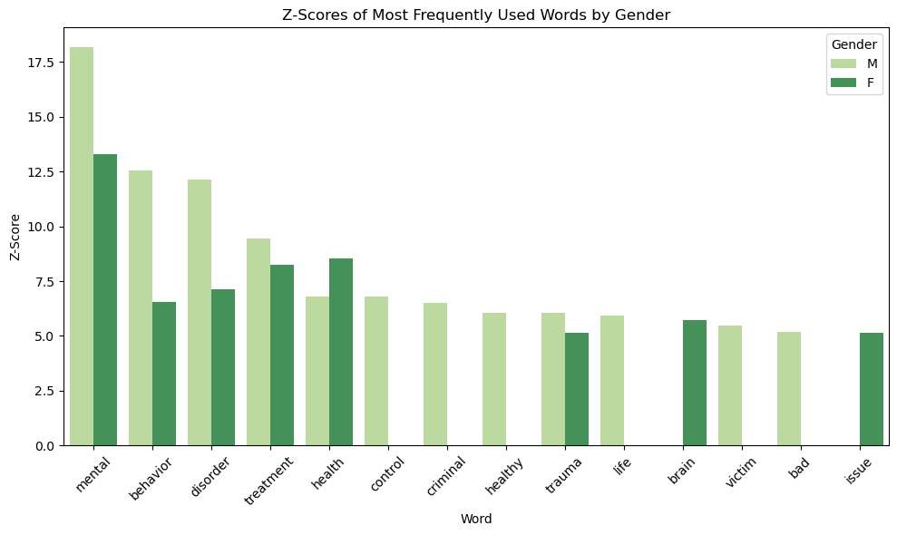

```python
# Function to count word frequencies
def count_word_frequencies(df, group_col):
    word_counts = {}
    for group, group_df in df.groupby(group_col):
        transcripts = group_df['Cleaned_Transcript']
        words = ' '.join(transcripts).split()
        word_counts[group] = {word: words.count(word) for word in set(words)}
    return word_counts

# Calculate word frequencies for each gender
word_frequencies = count_word_frequencies(dfQUAL, 'Gender')

# Create a DataFrame to store word frequencies for each gender
word_freq_df = pd.DataFrame({
    'Word': list(word_frequencies['M'].keys()) + list(word_frequencies['F'].keys()),
    'Gender': ['M'] * len(word_frequencies['M']) + ['F'] * len(word_frequencies['F']),
    'Frequency': list(word_frequencies['M'].values()) + list(word_frequencies['F'].values())
})

# Calculate z-scores for word frequencies for each gender
word_freq_df['Z_Score'] = word_freq_df.groupby('Gender')['Frequency'].transform(lambda x: zscore(x))

# Plot z-scores for each gender
plt.figure(figsize=(10, 6))
sns.barplot(data=word_freq_df.sort_values(by='Z_Score', ascending=False).head(20),
            x='Word', y='Z_Score', hue='Gender', palette='YlGn')
plt.title('Z-Scores of Most Frequently Used Words by Gender')
plt.xlabel('Word')
plt.ylabel('Z-Score')
plt.xticks(rotation=45)
plt.legend(title='Gender')
plt.axhline(0, color='black', linestyle='--', linewidth=0.5)  # Add zero line for reference
plt.tight_layout()
plt.show()
```

## STM (by computing LDA with Metadata)

Cleaning for STM:

```python
#### STM

## Clean and preprocess text data

# Get English stop words list
stop_words = set(stopwords.words('english'))

# Custom removal of words
custom_stop_words = ['think', 'know', 're', 'would', 'going', 'they', 'things', 'got',
                     'get', 'want', 'way', 'try', 'lot', 'make', 'see', 'go', 'may',
                     'say', 'something', 'people', 'person', 'really', 'someone', 'come',
                     'came', 'small', 'kind', 'could', 'even', 'like', 'much', 'less',
                     'hear', 'worse', 'sense', 'time', 'well', 'consider', 'still', 'give',
                     'na', 'gon','sides','situation', 'seeing', 'let', 'weeks', 'somebody',
                     'put', 'one', 'two', 'full','front', 'play', 'never', 'whether',
                     'leave', 'cars', 'generally', 'place', 'compared', 'found',
                     'background', 'us', 'gonna', 'thing', 'issue', 'issues', 'factor']
stop_words = stop_words.union(custom_stop_words)
stop_words = list(stop_words)

# Define contraction mapping dictionary
contractions_mapping = {
    "i'm": "i am", "i've": "i have", "i'll": "i will", "we're": "we are",
    "we've": "we have", "we'll": "we will", "you're": "you are", "you've": "you have",
    "you'll": "you will", "he's": "he is", "he'll": "he will", "she's": "she is",
    "she'll": "she will", "it's": "it is", "it'll": "it will",
    "they're": "they are", "they've": "they have", "they'll": "they will" }

# Function to expand contractions
def expand_contractions(text, contractions_mapping):
    pattern = re.compile(r'\b(' + '|'.join(contractions_mapping.keys()) + r')\b')
    def expand_match(contraction):
        return contractions_mapping[contraction.group(0)]
    expanded_text = pattern.sub(expand_match, text)
    return expanded_text

# Function to clean and preprocess text
def clean_text(text):
    tokens = word_tokenize(text)# Tokenize the text
    text = re.sub('[^A-Za-z]', ' ', text) # Remove non-alphabetic characters
    text = text.lower() # Convert to lowercase
    text = expand_contractions(text, contractions_mapping) # Expand contractions
    text = re.sub(r'[^\w\s]', ' ', text.lower()) # Remove punctuation and convert to lowercase
    cleaned_text = ' '.join([word for word in tokens if word not in stop_words]) # Remove stopwords
    return cleaned_text

# Apply cleaning
dfQUAL['TranscriptFull'] = dfQUAL['TranscriptFull'].apply(clean_text)
```

### Graph STMs

```
Topic 1:
trauma behavior sometimes better healthy control deal decision bad organic

Topic 2:
disorder mental treatment single choice incarcerated look young learn responsible

Topic 3:
disorder criminal mental control life trauma victim justice system better

Topic 4:
sentencing ptsd trigger help mental involuntary situations behavior community problems

Topic 5:
mental disorder sentence behavior treatment healthy justice criminal good also

Topic 6:
mental behavior treatment disorder health brain need trauma healthy change

Topic 7:
mental good health behavior court child brain control dealing victim

Topic 8:
behavior biology algorithms bad research choose data showing defender focus

         Topic 1   Topic 2   Topic 3   Topic 4   Topic 5   Topic 6   Topic 7  \
Gender
F       0.002404  0.002402  0.102120  0.002402  0.002402  0.783746  0.102122
M       0.042132  0.083214  0.184286  0.042169  0.115972  0.448641  0.042037

         Topic 8
Gender
F       0.002401
M       0.041549
```

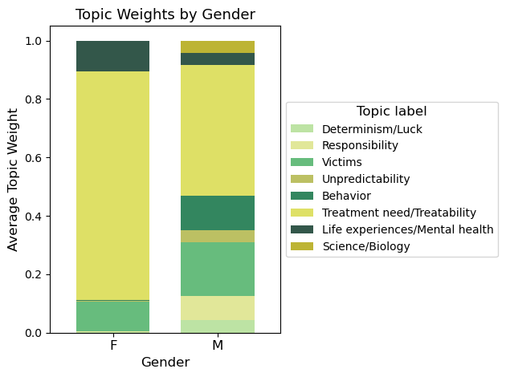

```python
### PLOT 1 example - Gender

### Create document-term matrix
vectorizer = CountVectorizer(stop_words=stop_words)
dtm = vectorizer.fit_transform(dfQUAL['TranscriptFull'])

# Prepare metadata
metadata = dfQUAL[['Gender']].values

# One-hot encode metadata
encoder = OneHotEncoder()
metadata_encoded = encoder.fit_transform(metadata)

# Combine document-term matrix and metadata
dtm_with_metadata = np.hstack((dtm.toarray(), metadata_encoded.toarray()))

# Define and train LDA model with metadata (using n topics)
lda_model_with_metadata = LatentDirichletAllocation(n_components=8, random_state=42)
lda_model_with_metadata.fit(dtm_with_metadata)

### Print the top words for each topic
feature_names = vectorizer.get_feature_names_out()
n_top_words = 10
for topic_idx, topic in enumerate(lda_model_with_metadata.components_):
    print(f"Topic {topic_idx + 1}:")
    print(" ".join([feature_names[i] for i in topic.argsort()[:-n_top_words - 1:-1]]))
    print()

# Analyze relationship between topics and metadata
topic_weights = lda_model_with_metadata.transform(dtm_with_metadata)
df_topics = pd.DataFrame(topic_weights, columns=[f'Topic {i+1}' for i in range(8)])
df_topics['Gender'] = dfQUAL['Gender']
print(df_topics.groupby('Gender').mean())

# Calculate average topic weights for each metadata category
avg_topic_weights = df_topics.groupby('Gender').mean()

### Plotting
Gcolors = ['#ADDD8E', '#DAE180', '#41AB5D', '#ACB13C', '#006837', '#D6D940', '#002D1D', '#ADA101']

Gtopic_labels = ['Determinism/Luck', 'Responsibility', 'Victims',
                'Unpredictability', 'Behavior', 'Treatment need/Treatability',
                'Life experiences/Mental health', 'Science/Biology']

plt.figure(figsize=(8, 10))

# Plot the average topic weights
avg_topic_weights.plot(kind='bar', stacked=True, color=Gcolors, alpha=0.8, width=0.7)

# Params
plt.xlabel('Gender', fontsize=12)
plt.ylabel('Average Topic Weight', fontsize=12)
plt.title('Topic Weights by Gender', fontsize=13)
plt.xticks(rotation=0, fontsize=12)

plt.legend(labels=Gtopic_labels, title='Topic label', loc='center left', bbox_to_anchor=(1, 0.5), fontsize=10)

plt.setp(plt.gca().get_legend().get_title(), fontsize=12)

plt.tight_layout()
plt.show()
```

```
Topic 1:
trauma behavior treatment control healthy sometimes luck getting part better

Topic 2:
victim behavior mental life condition medical schizophrenia information illness public

Topic 3:
mental disorder need sentence treatment trauma dangerous maybe defendant health

Topic 4:
treatment mental brain health victim right behavior public healthy able

Topic 5:
mental behavior disorder control better treatment life believe problem health

Topic 6:
disorder mental brain society point criminal punishment trying maybe different

Topic 7:
behavior treatment healthy mental science dangerous bad system jail evidence

Topic 8:
mental disorder health community help treatment sentencing ptsd trauma brain

          Topic 1   Topic 2   Topic 3   Topic 4   Topic 5   Topic 6   Topic 7  \
Geo
West     0.048360  0.156437  0.084961  0.168116  0.143108  0.120755  0.001872
MidWest  0.163681  0.100345  0.000952  0.000952  0.162159  0.000952  0.162680
South    0.000449  0.000449  0.321042  0.000449  0.242904  0.080972  0.233109

          Topic 8
Geo
West     0.276391
MidWest  0.408280
South    0.120627
```

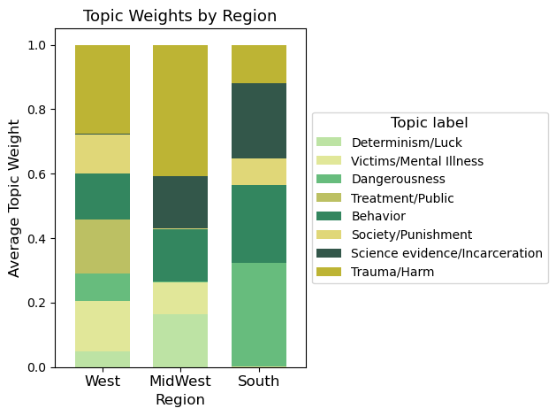

```python
#### PLOT 2 example - U.S. region

### Create document-term matrix
vectorizer = CountVectorizer(stop_words=stop_words)
dtm = vectorizer.fit_transform(dfQUAL['TranscriptFull'])

# Prepare metadata
metadata = dfQUAL[['Geo']].values

# One-hot encode metadata
encoder = OneHotEncoder()
metadata_encoded = encoder.fit_transform(metadata)

# Combine document-term matrix and metadata
dtm_with_metadata = np.hstack((dtm.toarray(), metadata_encoded.toarray()))

# Define and train LDA model with metadata (using n topics)
lda_model_with_metadata = LatentDirichletAllocation(n_components=8, random_state=42)
lda_model_with_metadata.fit(dtm_with_metadata)

### Print the top words for each topic
feature_names = vectorizer.get_feature_names_out()
n_top_words = 10
for topic_idx, topic in enumerate(lda_model_with_metadata.components_):
    print(f"Topic {topic_idx + 1}:")
    print(" ".join([feature_names[i] for i in topic.argsort()[:-n_top_words - 1:-1]]))
    print()

# Analyze relationship between topics and metadata
topic_weights = lda_model_with_metadata.transform(dtm_with_metadata)
df_topics = pd.DataFrame(topic_weights, columns=[f'Topic {i+1}' for i in range(8)])
df_topics['Geo'] = dfQUAL['Geo']
print(df_topics.groupby('Geo').mean())

# Calculate average topic weights for each metadata category
avg_topic_weights = df_topics.groupby('Geo').mean()

### Plotting
Geocolors = ['#ADDD8E', '#DAE180', '#41AB5D', '#ACB13C', '#006837', '#D9CD56', '#002D1D', '#ADA101']

Geotopic_labels = ['Determinism/Luck', 'Victims/Mental Illness', 'Dangerousness',
                'Treatment/Public', 'Behavior', 'Society/Punishment',
                'Science evidence/Incarceration', 'Trauma/Harm']

plt.figure(figsize=(8, 10))

# Plot the average topic weights
avg_topic_weights.plot(kind='bar', stacked=True, color=Geocolors, alpha=0.8, width=0.7)

# Params
plt.xlabel('Region', fontsize=12)
plt.ylabel('Average Topic Weight', fontsize=12)
plt.title('Topic Weights by Region', fontsize=13)
plt.xticks(rotation=0, fontsize=12)

plt.legend(labels=Geotopic_labels, title='Topic label', loc='center left', bbox_to_anchor=(1, 0.5), fontsize=10)

plt.setp(plt.gca().get_legend().get_title(), fontsize=12)

plt.tight_layout()
plt.show()
```

## Conclusions

Both the summary statistics and NLP findings point towards there existing differences in the way that judges with different characteristics (whether age/gender or their region/politics) make decisions in criminal cases. Given the relatively small sample of judges, inferential statistics would not necessarily shed more light on these differences. A good approch would be to perform further qualitative analyses on the intervie transcripts.

Please note that this notebook contains only a small example from the analyses performed for this project. The purpose of this notebook is to demonstrate the thought process and types of analyses performed and is not exhaustive or complete. The full analyses performed for each project are reported in the published article.

Dr. Mia Thomaidou (2024)